# Snow Data Assignment: Web Scraping, Functions, and Iteration

Amanda Hastings

2022-02-15

# Simple web scraping

R can read html using either rvest, xml, or xml2 packages. Here we are going to navigate to the Center for Snow and Avalance Studies [Website](https://snowstudies.org/archived-data/) and read a table in. This table contains links to data we want to programmatically download for three sites. We don’t know much about these sites, but they contain incredibly rich snow, temperature, and precip data.

## Reading an html

### Extract CSV links from webpage

```r
site_url <- 'https://snowstudies.org/archived-data/'

#Read the web url
webpage <- read_html(site_url)

#See if we can extract tables and get the data that way
tables <- webpage %>%
  html_nodes('table') %>%
  magrittr::extract2(3) %>%
  html_table(fill = TRUE)
#That didn't work, so let's try a different approach

#Extract only weblinks and then the URLs!
links <- webpage %>%
  html_nodes('a') %>%
  .[grepl('24hr',.)] %>%
  html_attr('href')
```

## Data Download

### Download data in a for loop

```r
#Grab only the name of the file by splitting out on forward slashes
splits <- str_split_fixed(links,'/',8)

#Keep only the 8th column
dataset <- splits[,8]

#generate a file list for where the data goes
file_names <- paste0('data/',dataset)

for(i in 1:3){
  download.file(links[i],destfile=file_names[i])
}

downloaded <- file.exists(file_names)

evaluate <- !all(downloaded)
```

### Download data in a map

```r
#Map version of the same for loop (downloading 3 files)
if(evaluate == T){
  map2(links[1:3],file_names[1:3],download.file)
}else{print('data already downloaded')}
```

```
## [[1]]
## [1] 0
##
## [[2]]
## [1] 0
##
## [[3]]
## [1] 0
```

## Data read-in

### Read in just the snow data as a loop

```r
#Pattern matching to only keep certain files
snow_files <- file_names %>%
  .[!grepl('SG_24',.)] %>%
  .[!grepl('PTSP',.)]

#empty_data <- list()

# snow_data <- for(i in 1:length(snow_files)){
#   empty_data[[i]] <- read_csv(snow_files[i]) %>%
#     select(Year,DOY,Sno_Height_M)
# }

#snow_data_full <- do.call('rbind',empty_data)

#summary(snow_data_full)
```

### Read in the data as a map function

```r
our_snow_reader <- function(file){
  name = str_split_fixed(file,'/',2)[,2] %>%
    gsub('_24hr.csv','',.)
  df <- read_csv(file) %>%
    select(Year,DOY,Sno_Height_M) %>%
    mutate(site = name)
}

snow_data_full <- map_dfr(snow_files,our_snow_reader)
summary(snow_data_full)
```

```
##       Year           DOY         Sno_Height_M        site
##  Min.   :2003   Min.   :  1.0   Min.   :-3.523   Length:12786
##  1st Qu.:2008   1st Qu.: 92.0   1st Qu.: 0.350   Class :character
##  Median :2012   Median :183.0   Median : 0.978   Mode  :character
##  Mean   :2012   Mean   :183.1   Mean   : 0.981
##  3rd Qu.:2016   3rd Qu.:274.0   3rd Qu.: 1.520
##  Max.   :2021   Max.   :366.0   Max.   : 2.905
##                                 NA's   :4554
```

### Plot snow data

```r
snow_yearly <- snow_data_full %>%
  group_by(Year,site) %>%
  summarize(mean_height = mean(Sno_Height_M,na.rm=T))
```

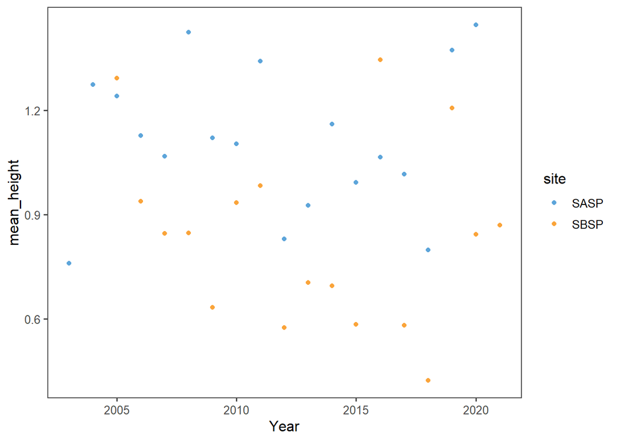

```r
ggplot(snow_yearly,aes(x=Year,y=mean_height,color=site)) +
  geom_point() +
  ggthemes::theme_few() +
  ggthemes::scale_color_few()
```

# Assignment:

1. Extract the meteorological data URLs. Here we want you to use the `rvest` package to get the URLs for the `SASP forcing` and `SBSP_forcing` meteorological datasets.

### Extract meteorological data URLS from website

```r
# Extract data URLs for SASP forcing and SBSP forcing datasets

site_url2 <- 'https://snowstudies.org/archived-data/'

webpage2 <- read_html(site_url2)

links2 <- webpage2 %>%
  html_nodes('a') %>%
  .[grepl('forcing',.)] %>%
  html_attr('href')

links2
```

```
## [1] "https://snowstudies.org/wp-content/uploads/2022/02/SBB_SASP_Forcing_Data.txt"
## [2] "https://snowstudies.org/wp-content/uploads/2022/02/SBB_SBSP_Forcing_Data.txt"
```

2. Download the meteorological data. Use the `download_file` and `str_split_fixed` commands to download the data and save it in your data folder. You can use a for loop or a map function.

### Download data and save it within data folder

```r
# Download the data and save within data folder

splits2 <- str_split_fixed(links2,'/',8)

dataset2 <- splits2[,8]

filenames2 <- paste0('data/',dataset2)

# Download data in a for loop

# for (i in 1:length(filenames2)) {
#   download.file(links2[i], destfile = filenames2[i])
# }

# Utilize map2() to download data

map2(links2,filenames2,download.file)
```

```
## [[1]]
## [1] 0
##
## [[2]]
## [1] 0
```

3. Write a custom function to read in the data and append a site column to the data.

### Write function to read in data and append site column to the data

```r
# This code grabs the variable names from the metadata pdf file

library(pdftools)
```

```r
headers <- pdf_text('https://snowstudies.org/wp-content/uploads/2022/02/Serially-Complete-Metadata-text08.pdf') %>%
  readr::read_lines(.) %>%
  trimws(.) %>%
  str_split_fixed(.,'\\.',2) %>%
  .[,2] %>%
  .[1:26] %>%
  str_trim(side = "left")
headers
```

```
##  [1] "year"
##  [2] "month"
##  [3] "day"
##  [4] "hour"
##  [5] "minute"
##  [6] "second"
##  [7] "precip [kg m-2 s-1]"
##  [8] "sw down [W m-2]"
##  [9] "lw down [W m-2]"
## [10] "air temp [K]"
## [11] "windspeed [m s-1]"
## [12] "relative humidity [%]"
## [13] "pressure [Pa]"
## [14] "specific humidity [g g-1]"
## [15] "calculated dewpoint temperature [K]"
## [16] "precip, WMO-corrected [kg m-2 s-1]"
## [17] "air temp, corrected with Kent et al. (1993) [K]"
## [18] "air temp, corrected with Anderson and Baumgartner (1998)[K]"
## [19] "air temp, corrected with Nakamura and Mahrt (2005) [K]"
## [20] "air temp, corrected with Huwald et al. (2009) [K]"
## [21] "qc code precip"
## [22] "qc code sw down"
## [23] "qc code lw down"
## [24] "qc code air temp"
## [25] "qc code wind speed"
## [26] "qc code relhum"
```

```r
# Write a function to read in the data and append site column

forcing_files <- filenames2
#   .[!grepl('24hr',.)]
# forcing_files


file <- forcing_files[1]


forcefile_reader <- function(file) {
  name2 = str_split_fixed(file, '_', 3)[, 2]
    df <- read.csv(file, header = FALSE, sep = '') %>%
      select(V1, V2, V3, V7, V10) %>%
      rename(
        year = 1,
        month = 2,
        day = 3,
        precip = 4,
        airtemp = 5
      ) %>%
      mutate(site = name2)

}
```

4. Use the `map` function to read in both meteorological files. Display a summary of your tibble.

### Read in meterological data files with map function

```r
# Use map function to read in meteorological files

forcing_data_full <- map_dfr(forcing_files, forcefile_reader)

# # Display summary as tibble

library(tibble)
forcing_tibble <-as_tibble(forcing_data_full)
summary(forcing_tibble)
```

```
##       year          month             day            precip
##  Min.   :2003   Min.   : 1.000   Min.   : 1.00   Min.   :0.000e+00
##  1st Qu.:2005   1st Qu.: 3.000   1st Qu.: 8.00   1st Qu.:0.000e+00
##  Median :2007   Median : 6.000   Median :16.00   Median :0.000e+00
##  Mean   :2007   Mean   : 6.472   Mean   :15.76   Mean   :3.838e-05
##  3rd Qu.:2009   3rd Qu.: 9.000   3rd Qu.:23.00   3rd Qu.:0.000e+00
##  Max.   :2011   Max.   :12.000   Max.   :31.00   Max.   :6.111e-03
##     airtemp          site
##  Min.   :242.1   Length:138336
##  1st Qu.:265.8   Class :character
##  Median :272.6   Mode  :character
##  Mean   :272.6
##  3rd Qu.:279.7
##  Max.   :295.8
```

5. Make a line plot of mean temp by year by site (using the `air temp [K]` variable). Is there anything suspicious in the plot? Adjust your filtering if needed.

### Make line plot of mean temperature by year by site

```r
library(ggthemes)

# Create data frame with mean air temperature by year by site

temp_yearly <- forcing_data_full %>%
  filter(!year %in% 2003) %>%
  group_by(year,site) %>%
  summarize(mean_yrtemp = mean(airtemp, na.rm=T))
```

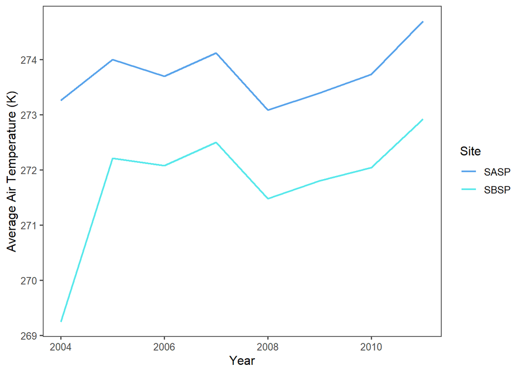

```r
# Make line plot of mean temperature by year by site

ggplot(temp_yearly, aes(x=year, y=mean_yrtemp, color=site))+
  geom_line(size=.75)+
  theme_few()+
  scale_color_manual(name="Site", values= c("#58A3EB","#58E8EB"))+
  labs(x='Year', y='Average Air Temperature (K)')
```

I filtered out 2003 given there were only records for two months out of the year.

6. Write a function that makes line plots of monthly average temperature at each site for a given year. Use a for loop to make these plots for 2005 to 2010. Are monthly average temperatures at the Senator Beck Study Plot ever warmer than the Snow Angel Study Plot? Hint: https://ggplot2.tidyverse.org/reference/print.ggplot.html

### Create function to make line plots of monthly average temperature at each site per year

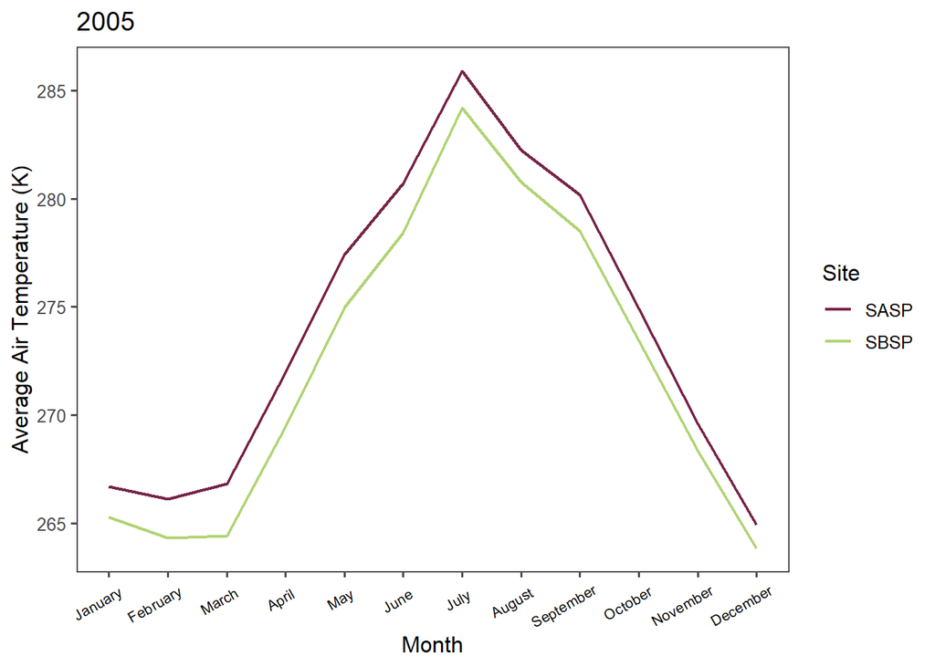

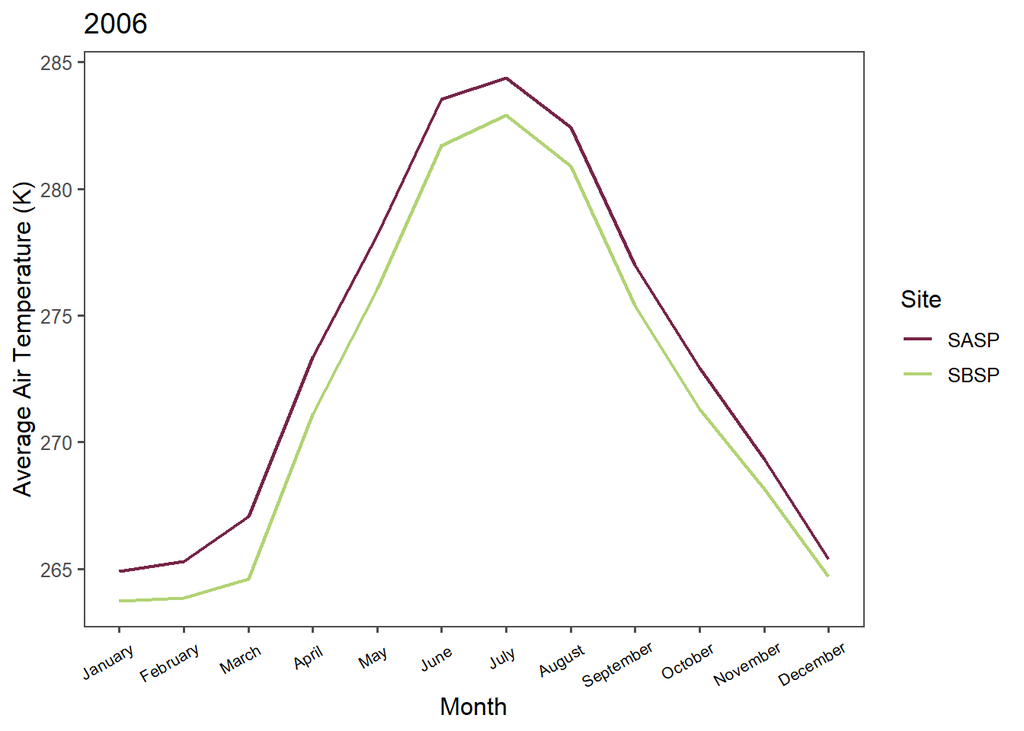

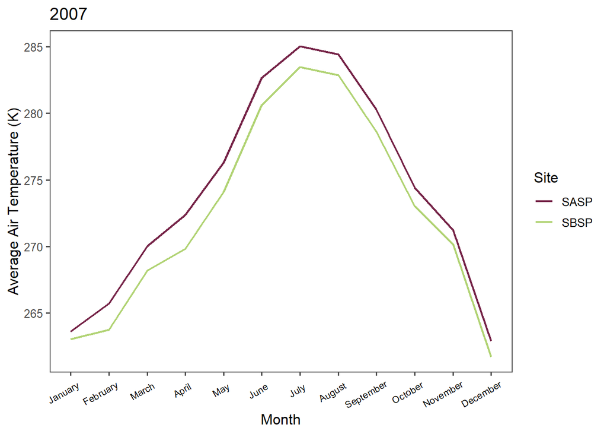

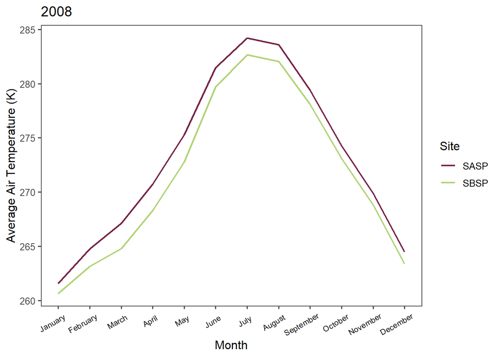

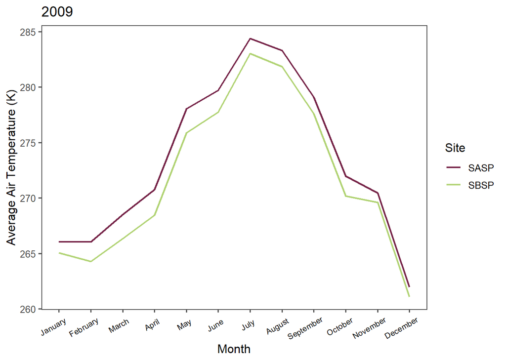

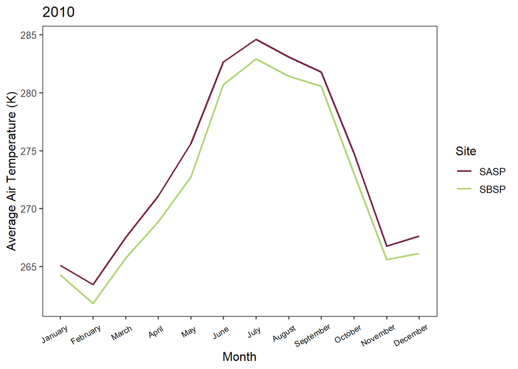

```r
# Write function to make line plots of monthly average temps per site per year

line_plotter <- function(df, year) {
  temp_monthly <- df %>%
    group_by(year, month, site) %>%
    summarize(mean_motemp = mean(airtemp, na.rm = T)) %>%
    filter(i == year)

  print(
    ggplot(temp_monthly, aes(
      x = month, y = mean_motemp, color = site
    )) +
      geom_line(size = .75) +
      theme_few() +
      scale_color_manual(name = "Site", values = c("#762448", "#B1D374")) +
      labs(x="Month",y = 'Average Air Temperature (K)', title = i)+
      scale_x_continuous(
        breaks = c(1, 2, 3, 4, 5, 6, 7, 8, 9, 10, 11, 12),
        labels = c(
          'January',
          'February',
          'March',
          'April',
          'May',
          'June',
          'July',
          'August',
          'September',
          'October',
          'November',
          'December'
        )
      ) +
      theme(
        axis.text.x = element_text(
          color = "black",
          size = 8,
          angle = 30,
          vjust = .8,
          hjust = .8
        )
      ))
}

# Use for loop to plot years 2005 to 2010

yrs = c(2005:2010)

for (i in yrs){
  line_plotter(forcing_data_full,year)
}
```

Bonus: Make a plot of average daily precipitation by day of year (averaged across all available years).

### Create a plot of average daily precip by day of year

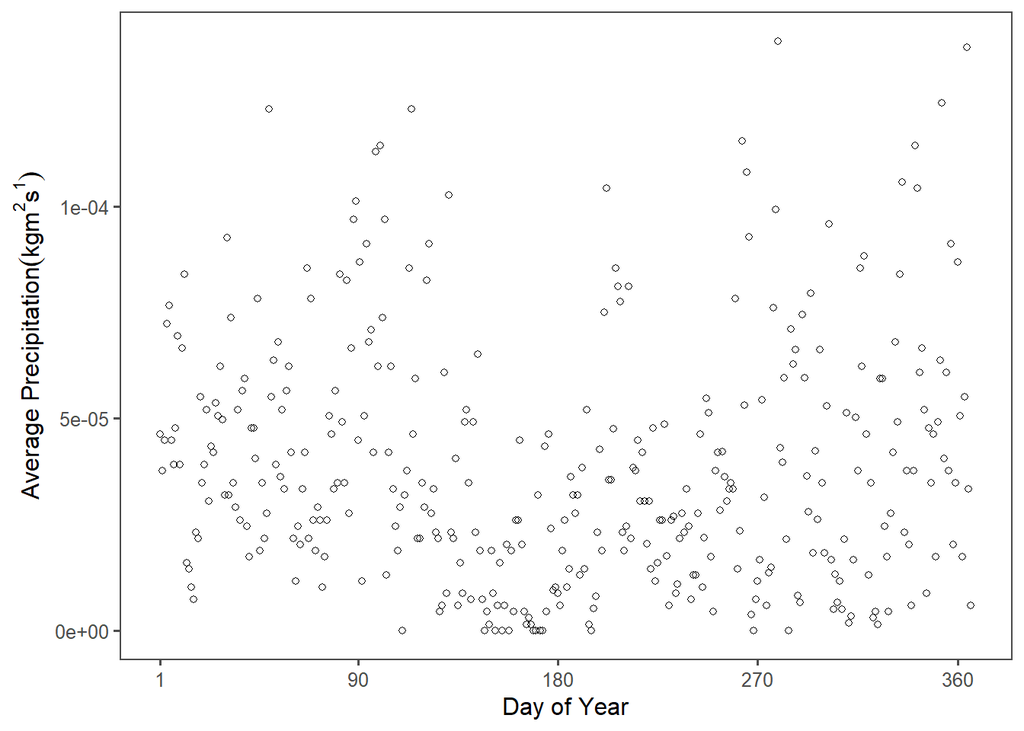

```r
# Create plot with mean daily precip by day of year using ggplot

# Add date column
# Use lubridate:: y day for day of year
precip_daily <- forcing_data_full %>%
  group_by(month, day, year, site) %>%
  summarize(mean_precip = mean(precip, na.rm = T)) %>%
  mutate(date = as.Date(paste(year, month, day, sep = "/"))) %>%
  mutate(yday = yday(date)) %>%
  pivot_wider(names_from = site, values_from = mean_precip) %>%
  select(-SBSP)%>%
  group_by(yday)%>%
  summarize(mean_dy_precip = mean(SASP))
ggplot(precip_daily, aes(x = yday, y = mean_dy_precip)) +
  geom_point(shape = 1) +
  theme_few() +
  labs(x = 'Day of Year', y = expression('Average Precipitation'~ ('kg'*m^2*s^1)))+
  scale_x_continuous(breaks=c(1,90,180,270,360))
```

```r
# Create plot with mean daily precip by day of year using dygraphs
# This is not averaged across available years

library(dygraphs)
library(xts)
library(lubridate)

precip_daily2 <- forcing_data_full %>%
  group_by(month, day, year, site) %>%
  summarize(mean_precip = mean(precip, na.rm = T)) %>%
  mutate(date = as.Date(paste(year, month, day, sep = "/"))) %>%
  pivot_wider(names_from = site, values_from = mean_precip) %>%
  ungroup() %>%
  select(-SBSP, -month, -day, -year)
precip_xts2 <- xts(precip_daily2 %>%
                     select(SASP), order.by = precip_daily2$date)

dygraph(precip_xts2, ylab = "Average Daily Precipitation") %>%
  dyOptions(fillGraph = TRUE, axisLabelFontSize=10)
```

[interactive chart not shown]

Bonus #2: Use a function and for loop to create yearly plots of precipitation by day of year.

### Create yearly plots of precip by day of year

#### Function using ggplot

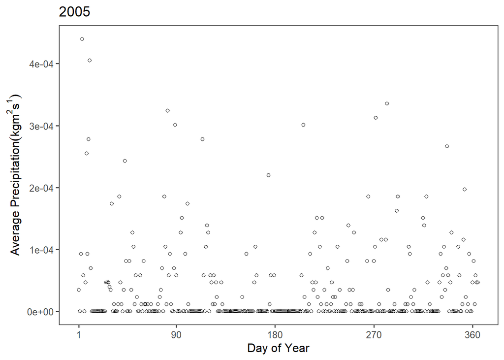

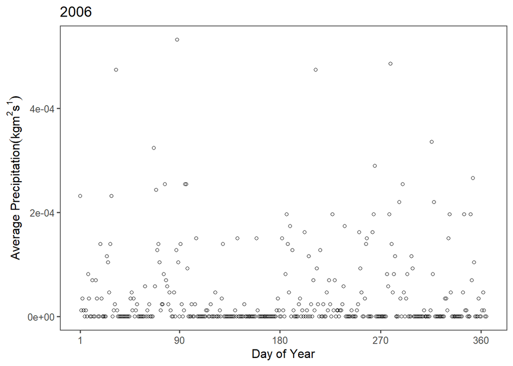

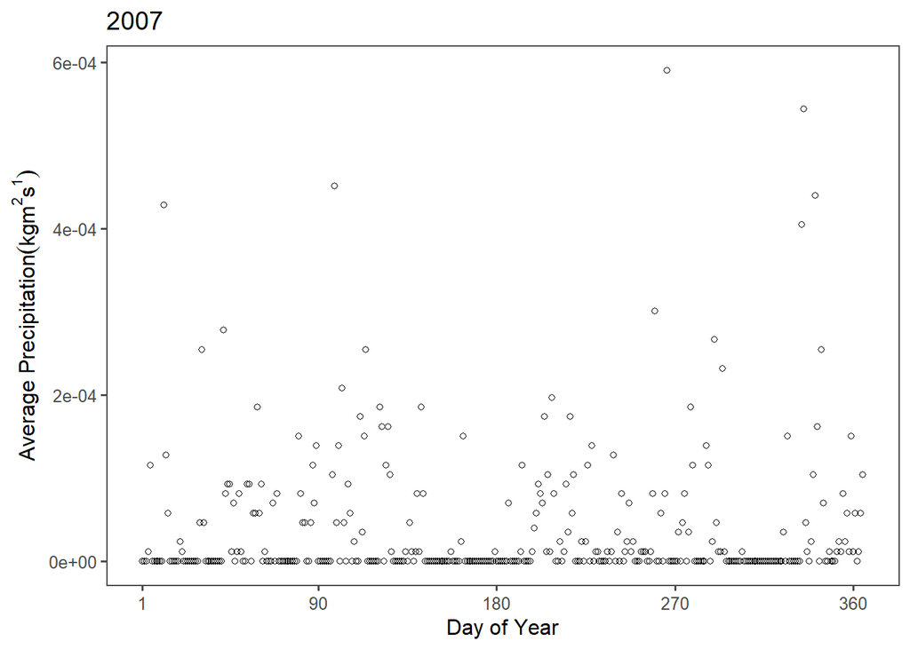

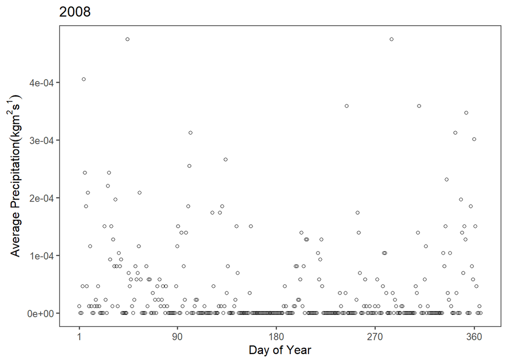

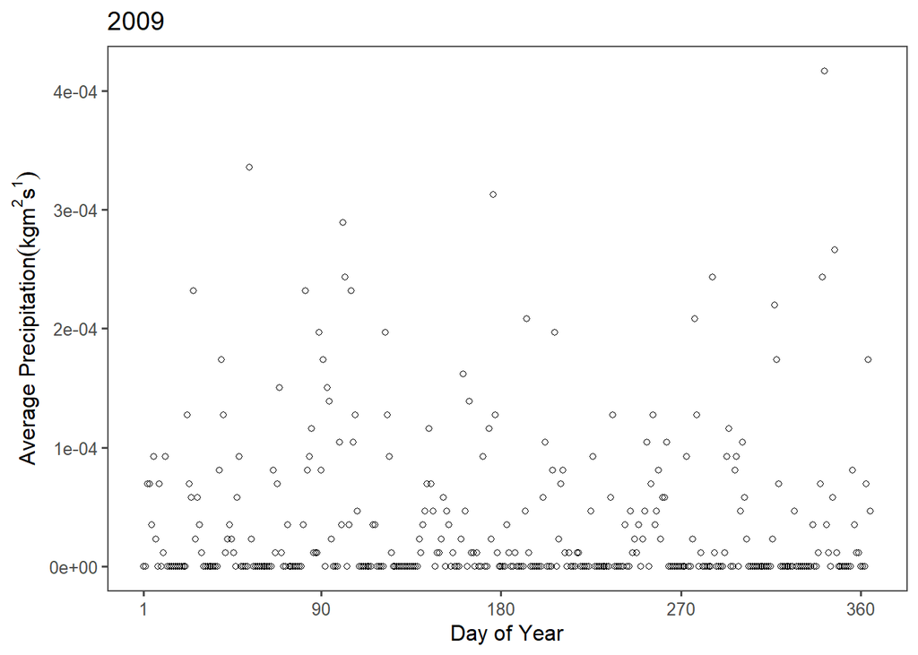

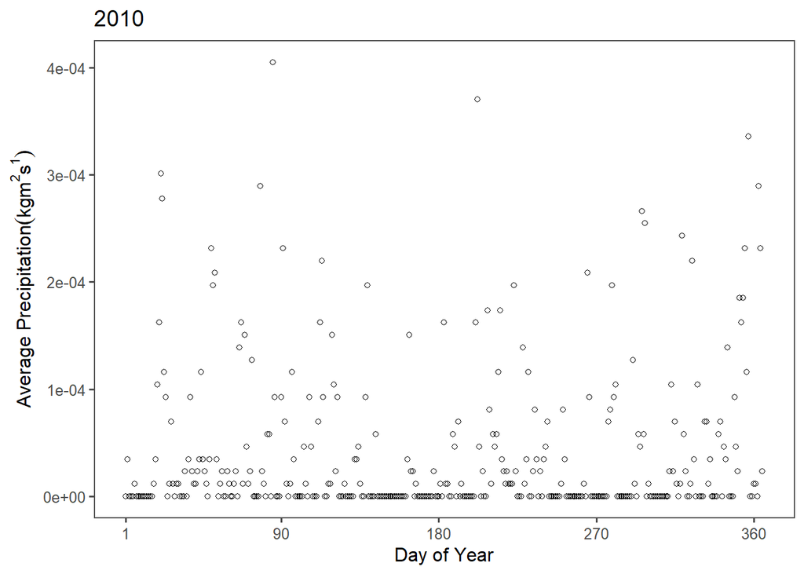

```r
# Write a function to create yearly plots for precip by day of year with ggplot

precip_plotter2 <- function(df, year) {
  precip_daily4 <- df %>%
    group_by(month, day, year, site) %>%
    summarize(mean_precip = mean(precip, na.rm = T)) %>%
    mutate(date = as.Date(paste(year, month, day, sep = "/"))) %>%
    mutate(yday = yday(date)) %>%
    pivot_wider(names_from = site, values_from = mean_precip) %>%
    select(-SBSP) %>%
    filter(year == i)

  print(
    ggplot(precip_daily4, aes(x = yday, y = SASP)) +
      geom_point(shape = 1) +
      theme_few() +
      labs(
        title = i,
        x = 'Day of Year',
        y = expression('Average Precipitation' ~ ('kg' *
                                                    m ^ 2 * s ^ 1))
      ) +
      scale_x_continuous(breaks = c(1, 90, 180, 270, 360))
  )
}

# Use for loop to plot years 2005 to 2010

yrs = c(2005:2010)

for (i in yrs){
  precip_plotter2(forcing_data_full,year)
}
```

#### Function using dygraphs

This will print the plots in the console/inline and the document will knit. However, the dygraphs plots do not show up in the final document.

```r
# Write function to create yearly plots of precipitation by day of year with dygraphs

dy_precip_plotter <- function(df, year) {
  precip_daily3 <- df %>%
    group_by(month, day, year, site) %>%
    summarize(mean_precip = mean(precip, na.rm = T)) %>%
    mutate(date = as.Date(paste(year, month, day, sep = "/"))) %>%
    pivot_wider(names_from = site, values_from = mean_precip) %>%
    filter(year == i) %>%
    ungroup() %>%
    select(-SBSP,-month,-day,-year)

  precip_xts3 <- xts(precip_daily3 %>%
                      select(SASP), order.by = precip_daily3$date)

  print(
    dygraph(precip_xts3, main = i, ylab = "Average Daily Precipitation") %>%
      dyOptions(fillGraph = TRUE, axisLabelFontSize=10)
  )
}

# Use for loop to plot years 2005 to 2010

yrs = c(2005:2010)

for (i in yrs){
  dy_precip_plotter(forcing_data_full,year)
}
```